# Финансоые риски.Тест

A.Doynikov,

2/5/2021

# Цели теста

Оценка различных рыночных рисков финансовых инструментов

## Текст задания

Текст задания одинаков для всех вариантов, разные только данные в каждом варианте.

- Импортировать дневные цены закрытия перечисленных товаров,валют, индексов и акций Вашего варианта за 2020-21 год с 5 февраля 2020 года по 5 февраля 2021 года включительно в файл `Asset.csv` (см. указание к импорту). Данные специально взяты за 2020-2021 год, чтобы исключить влияние событий на Украине.

**Внимательно вводите дату начала и окончания с 5 февраля 2020 года по 5 февраля 2021 года. Программа проверки результатов настроена строго только на этот период**

### Указание к импорту

Импорт данных в Windows производится следующим образом. Как это делается в Linux и на Mac не знаю. Но наверняка там есть что-то похожее.

- Войдите в приложение по импорту данных по соответствующей каждому инструменту ссылке
- Установите даты начала и окончания импорта
- Тип выходного файла `*.csv`
- Установите формат даты, совпадающий с тем, что установлен у Вас в настройках даты и времени Вашего компьютера
- Разделитель полей установите ,(запятая)
- Далее нажмите клавишу “Получить файл”

Пример правильно импортированного файла

[figure not shown]

Loaded File

- Удалите все ненужные столбцы кроме DATE CLOSE
- Оставшийся файл будет выглядеть следующим образом

[figure not shown]

- Сохраните файл в `Asset.csv` формате csv. Формат csv это текстовый формат, где столбцы разделяются символом “,”.
- Импортируйте данные в R (любители Python также наверняка с этим справятся)

```r
asset <- read.table("Asset.csv",header=TRUE,sep=',',row.names = 1)
head(asset)
```

```
##           X.CLOSE.
## 2/5/2020    232.56
## 2/6/2020    231.38
## 2/7/2020    229.11
## 2/10/2020   225.20
## 2/11/2020   233.90
## 2/12/2020   238.03
```

```r
tail(asset)
```

```
##           X.CLOSE.
## 1/29/2021   212.83
## 2/1/2021    214.66
## 2/2/2021    214.42
## 2/3/2021    218.10
## 2/4/2021    219.79
## 2/5/2021    221.58
```

```r
imoex<- read.table("IMOEX.csv",header=TRUE,sep=',',row.names = 1)
head(imoex)
```

```
##             IMOEX
## 2/5/2020  3114.25
## 2/6/2020  3096.68
## 2/7/2020  3087.63
## 2/10/2020 3062.41
## 2/11/2020 3097.58
## 2/12/2020 3122.27
```

```r
tail(imoex)
```

```
##             IMOEX
## 1/29/2021 3277.08
## 2/1/2021  3291.14
## 2/2/2021  3360.25
## 2/3/2021  3343.46
## 2/4/2021  3372.00
## 2/5/2021  3392.73
```

Аналогично получите файл `IMOEX.csv` индекса Мос. биржи

Индекс Мос.биржи

https://www.finam.ru/profile/mirovye-indeksy/micex/export/

- Постройте графики импортированных данных для наглядности

```r
library(PerformanceAnalytics)
```

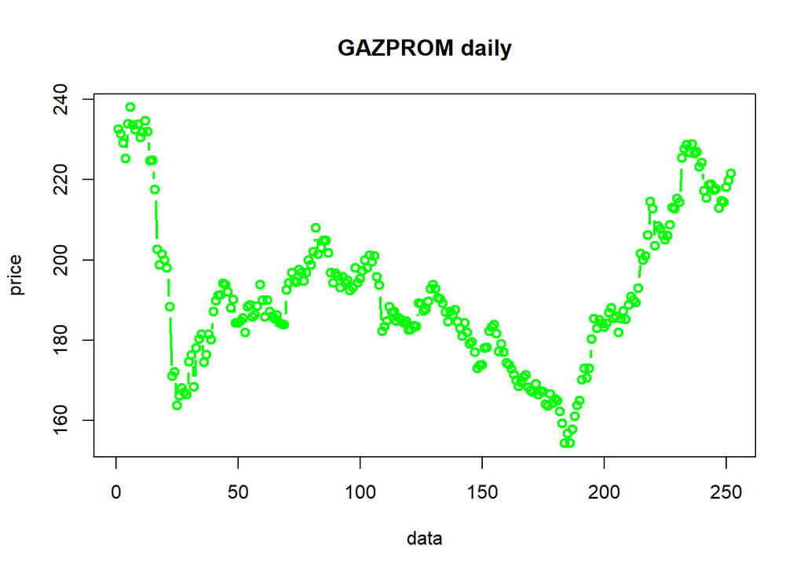

```r
colnames(asset)<- c("GAZPROM")
plot(asset$GAZPROM,type = 'b',main="GAZPROM daily",pch = 21, col = "green",lwd = 2,xlab= 'data',ylab = "price" )
```

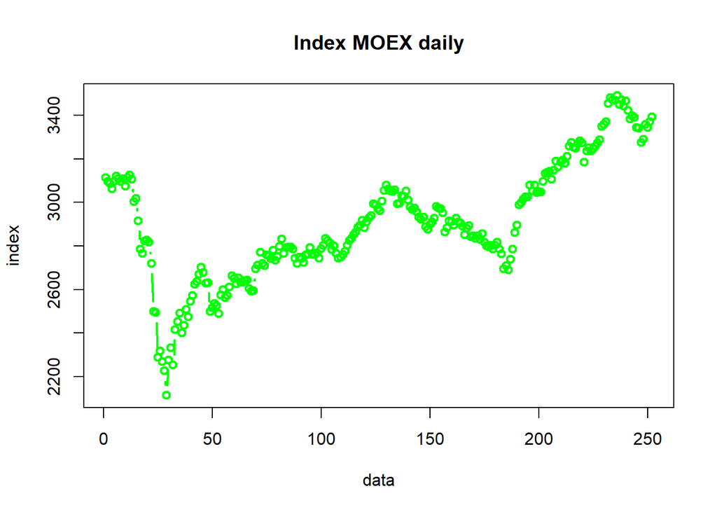

```r
colnames(imoex)<- c("IMOEX")
plot(imoex$IMOEX,type = 'b',main="Index MOEX daily",pch = 21, col = "green",lwd = 2,xlab= 'data',ylab = "index" )
```

- Перейти к логарифмическим доходностям в акциях и по индексу по формуле

$$r_t=ln(S_t/S_{t-1})=ln(S_t)-ln(S_{t-1})$$
Предположим, что безрисковая доходность равна 4%.

```r
  Rf <-0.04


len<-  dim(asset)[1]
r1 <- diff(log(asset$GAZPROM))
r2 <- diff(log(imoex$IMOEX))
rates <- cbind(r1,r2)


colnames(rates)<- c("GAZPROM","IMOEX")
rownames(rates)<-as.character(as.Date(rownames(asset)[2:len],"%m/%d/%Y"))
head(rates)
```

```
##                 GAZPROM        IMOEX
## 2020-02-06 -0.005086876 -0.005657783
## 2020-02-07 -0.009859143 -0.002926764
## 2020-02-10 -0.017213341 -0.008201619
## 2020-02-11  0.037904777  0.011418974
## 2020-02-12  0.017503043  0.007939140
## 2020-02-13 -0.019000529 -0.003921498
```

- вычислить вручную или с помощью библиотеки коэффициент `beta` для актива варианта.

(Skipped Code)

```
## [1] 0.9012622
```

- вычислить вручную или с помощью библиотеки коэффициент `alpha` для актива варианта.

(Skipped Code)

```
## [1] -0.004449731
```

- вычислить вручную или с помощью библиотеки коэффициент `sharp` для портфеля из купленного одного актива варианта.

(Skipped Code)

```
##                                    [,1]
## StdDev Sharpe (Rf=4%, p=95%): -2.108924
```

- вычислить вручную или с помощью библиотеки коэффициент нормального VaR уровня 0.95 для доходностей одного актива варианта.

(Skipped Code)

```
##         GAZPROM
## VaR -0.03147843
```

- вычислить вручную или с помощью библиотеки коэффициент исторического VaR уровня 0.95 для доходностей одного актива варианта.

(Skipped Code)

```
##         GAZPROM
## VaR -0.03131732
```

- вычислить вручную или с помощью библиотеки коэффициент исторического Shortfall уровня 0.95 для доходностей одного актива варианта.

(Skipped Code)

```
##        GAZPROM
## ES -0.04743915
```

- вычислить вручную или с помощью библиотеки коэффициент `gaussian` Shortfall уровня 0.95 для доходностей одного актива варианта.

(Skipped Code)

```
##        GAZPROM
## ES -0.03942627
```

```r
res <- list(
  beta = beta,
    alpha = alpha,
    sharp=sharp[1],
    var_hist = var_hist,
    var_gauss= var_gauss,
    shortfall_gauss=shortfall_gauss,
    shortfall_hist=shortfall_hist
)
res
```

```
## $beta
## [1] 0.9012622
##
## $alpha
## [1] -0.004449731
##
## $sharp
## [1] -2.108924
##
## $var_hist
##         GAZPROM
## VaR -0.03131732
##
## $var_gauss
##         GAZPROM
## VaR -0.03147843
##
## $shortfall_gauss
##        GAZPROM
## ES -0.03942627
##
## $shortfall_hist
##        GAZPROM
## ES -0.04743915
```

Вариант 0 создан для тренировки. На этом варианте количество попыток не ограничено.

Количество попыток ограничено 10.

Сохраняется лучший результат.

Количество попыток ограничено 10. Запоминается также дата последней попытки.

**Внимание!!!Тест выполняется только для одного варианта. При необходимости смены варианта, запустите тест заново.**

Срок выполнения задания 1 неделя до следующей лекции.

Все замечания и вопросы рассматриваются только в течении 1-ой недели со дня выдачи теста.

Результаты Вашего варианта сохранятся в некоторый недоступный Вам файл.

Мне присылать ничего не надо. У меня есть возможность посмотреть Ваши результаты.

Результаты выполнения теста будут публиковаться в известном Вам приложении по мере выполнения.

Претензии принимаются по e-mail и будут рассмотрены в течении 1-го дня после публикации результатов.

Рекомендую запомнить экран с результатом в файл для предъявления при претензиях.

Тест вызывается по ссылке

https://shiny.ilykei.com/ANDoynikov/Tests_Prac/test2/

## Вариант 0

- Акции Газпрома https://www.finam.ru/profile/moex-akcii/gazprom/export/

## Вариант 1

- Акции Сургут нефть газ

https://www.finam.ru/profile/moex-akcii/surgut/export/

## Вариант 2

- Акции Алроса

https://www.finam.ru/profile/moex-akcii/alrosa-ao/export/

## Вариант 3

- Акции Аэрофлот

https://www.finam.ru/profile/moex-akcii/aeroflot/export/

## Вариант 4

- Акции ВТБ

https://www.finam.ru/profile/moex-akcii/vtb/export/

## Вариант 5

- Акции ГМК НорНикель

https://www.finam.ru/profile/moex-akcii/nornickel-gmk/export/

## Вариант 6

- Акции КАМАЗ

https://www.finam.ru/profile/moex-akcii/kamaz/export/

## Вариант 7

- Акции Лукойл

https://www.finam.ru/profile/moex-akcii/lukoil/export/

## Вариант 8

- Акции Роснефть

https://www.finam.ru/profile/moex-akcii/rosneft/export/

## Вариант 9

- Акции Ростелеком

https://www.finam.ru/profile/moex-akcii/rostelecom/export/

## Вариант 10

- Акции Сбербанк

https://www.finam.ru/profile/moex-akcii/sberbank/export/

## Вариант 11

- Акции Сургут нефть газ

https://www.finam.ru/profile/moex-akcii/surgut/export/

## Вариант 12

- Акции Алроса

https://www.finam.ru/profile/moex-akcii/alrosa-ao/export/

## Вариант 13

- Акции Аэрофлот

https://www.finam.ru/profile/moex-akcii/aeroflot/export/

## Вариант 14

- Акции ВТБ

https://www.finam.ru/profile/moex-akcii/vtb/export/

## Вариант 15

- Акции ГМК НорНикель

https://www.finam.ru/profile/moex-akcii/nornickel-gmk/export/

## Вариант 16

- Акции КАМАЗ

https://www.finam.ru/profile/moex-akcii/kamaz/export/

## Вариант 17

- Акции Лукойл

https://www.finam.ru/profile/moex-akcii/lukoil/export/

## Вариант 18

- Акции Роснефть

https://www.finam.ru/profile/moex-akcii/rosneft/export/

## Вариант 19

- Акции Ростелеком

https://www.finam.ru/profile/moex-akcii/rostelecom/export/

## Вариант 20

- Акции Сбербанк

https://www.finam.ru/profile/moex-akcii/sberbank/export/

## Вариант 21

- Акции Сургут нефть газ

https://www.finam.ru/profile/moex-akcii/surgut/export/

## Вариант 22

- Акции Алроса

https://www.finam.ru/profile/moex-akcii/alrosa-ao/export/

## Вариант 23

- Акции Аэрофлот

https://www.finam.ru/profile/moex-akcii/aeroflot/export/

## Вариант 24

- Акции ВТБ

https://www.finam.ru/profile/moex-akcii/vtb/export/

## Вариант 25

- Акции ГМК НорНикель

https://www.finam.ru/profile/moex-akcii/nornickel-gmk/export/

## Вариант 26

- Акции КАМАЗ

https://www.finam.ru/profile/moex-akcii/kamaz/export/

## Вариант 27

- Акции Лукойл

https://www.finam.ru/profile/moex-akcii/lukoil/export/

## Вариант 28

- Акции Роснефть

https://www.finam.ru/profile/moex-akcii/rosneft/export/

## Вариант 29

- Акции Ростелеком

https://www.finam.ru/profile/moex-akcii/rostelecom/export/

## Вариант 30

- Акции Сбербанк

https://www.finam.ru/profile/moex-akcii/sberbank/export/